# Coursera Practical Machine Learning Project

Dec. 2014

## 0. Background

Using devices such as Jawbone Up, Nike FuelBand, and Fitbit it is now possible to collect a large amount of data about personal activity relatively inexpensively. These type of devices are part of the quantified self movement – a group of enthusiasts who take measurements about themselves regularly to improve their health, to find patterns in their behavior, or because they are tech geeks. One thing that people regularly do is quantify how much of a particular activity they do, but they rarely quantify how well they do it. In this project, your goal will be to use data from accelerometers on the belt, forearm, arm, and dumbell of 6 participants. They were asked to perform barbell lifts correctly and incorrectly in 5 different ways. More information is available from the website here: http://groupware.les.inf.puc-rio.br/har (see the section on the Weight Lifting Exercise Dataset).

## 1. Preliminary steps

First, we load the required libraries and read the dataset and the test cases from CSV files:

```r
library(caret)
library(doParallel)
set.seed(999)
setwd("E:/DataAnalysis/R Projects/Coursera_Practical machine learning/Project/")
dataset = read.csv2("pml-training.csv", na.strings=c("NA","#DIV/0!"), sep=",", dec=".")
testcases = read.csv2("pml-testing.csv", na.strings=c("NA","#DIV/0!"), sep=",", dec=".")
```

We can check the size of the dataset and the distribution of the classes to predict:

```r
dim(dataset)
```

```
## [1] 19622   160
```

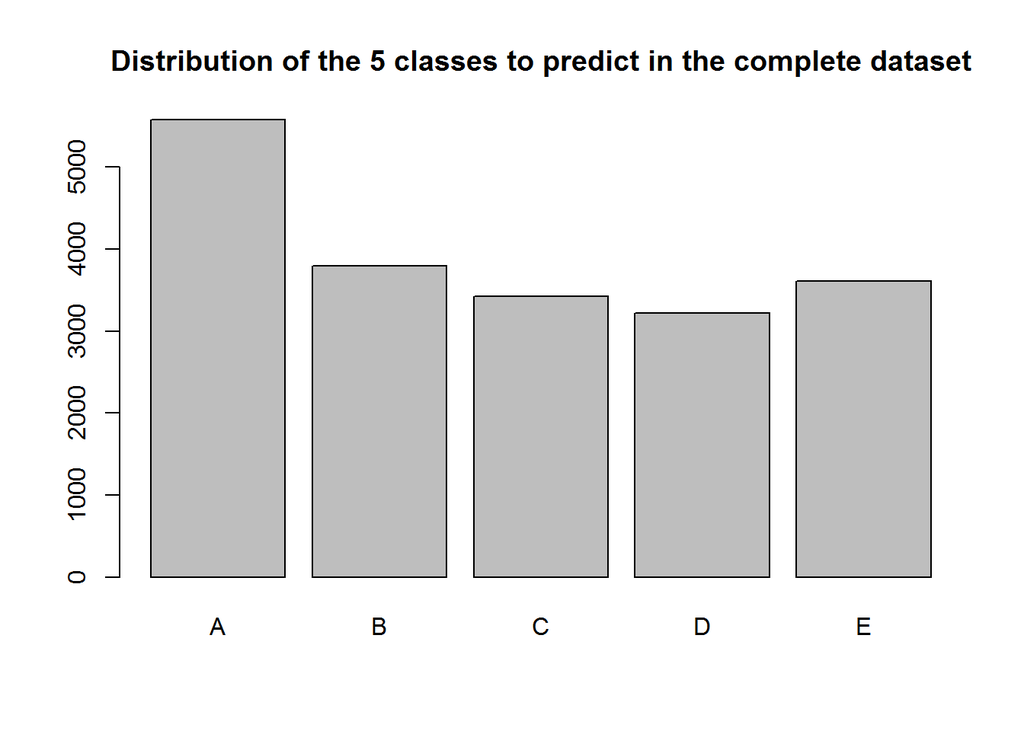

```r
plot(dataset$classe, main ="Distribution of the 5 classes to predict in the complete dataset")
```

## 2. Data preparation

The first 7 colums of the dataset are not relevant to make predictions, so we can remove them :

```r
list1 = c(1,2,3,4,5,6,7)
names(dataset[list1])
```

```
## [1] "X"                    "user_name"            "raw_timestamp_part_1"
## [4] "raw_timestamp_part_2" "cvtd_timestamp"       "new_window"
## [7] "num_window"
```

```r
filteredData <- dataset[-list1]
```

We can also remove the columns with a large number of NA values:

```r
list2 <- which((colSums(is.na(filteredData))/nrow(filteredData)) > 0.8)
length(list2)
```

```
## [1] 100
```

```r
filteredData <- filteredData[-list2]
```

To obtain faster computation time, we take a 25% sample of the dataset which will be used in the learning procedure. We keep the remaining of the data as a testing sample:

```r
partition <- createDataPartition(filteredData$classe, p=0.25, list=FALSE)
training <- filteredData[partition,]
testing <- filteredData[-partition,]
dim(training)
```

```
## [1] 4907   53
```

We can check that the distribution of the 5 classes to predict in the sample is the same as in the full dataset:

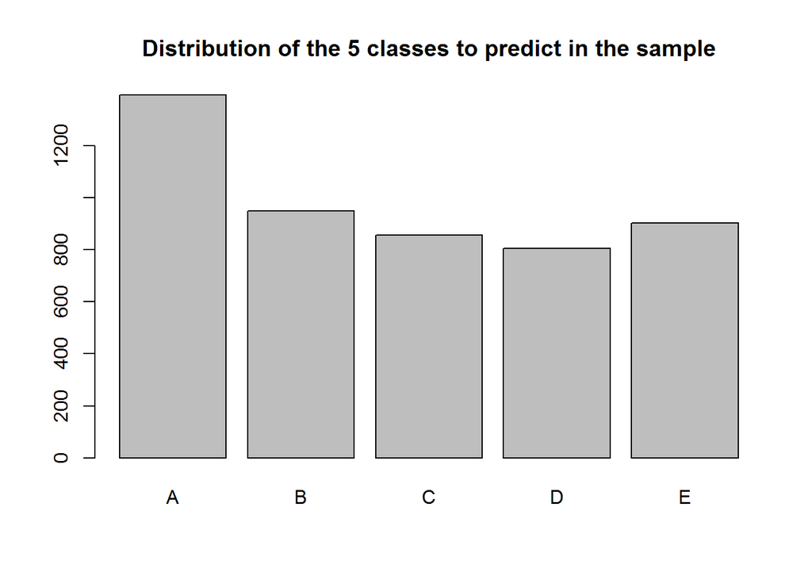

```r
plot(training$classe, main ="Distribution of the 5 classes to predict in the sample")
```

## 3. Building the model

We choose to use a Random Forest algorithm which seems to be appropriate to our situation:

- the predictors are numerical
- the parameter to predict is categorical
- there is no reason to suspect a linear relationship

Cross-validation is “baked in” the Random Forest algorithm : each tree is constructed with a different bootstrap sample from the data, and the data not used to contruct a tree is used to calculate an out-of-bag error estimate. For more details, see “The out-of-bag (oob) error estimate” at https://www.stat.berkeley.edu/~breiman/RandomForests/cc_home.htm

To improve computing time, we also make use of parallel processing as described here: http://stackoverflow.com/questions/13403427/fully-reproducible-parallel-models-using-caret

```r
cl <- makeCluster(detectCores()/2)
registerDoParallel(cl)
modFit1 <- train(classe~. , method="rf", data=training, prox=TRUE)
```

## 4. Model evaluation

We can display the evaluation provided by the Random Tree model itself, as well as the variable importance:

```r
print(modFit1$finalModel)
```

```
##
## Call:
##  randomForest(x = x, y = y, mtry = param$mtry, proximity = TRUE)
##                Type of random forest: classification
##                      Number of trees: 500
## No. of variables tried at each split: 27
##
##         OOB estimate of  error rate: 1.83%
## Confusion matrix:
##      A   B   C   D   E class.error
## A 1391   2   2   0   0 0.002867384
## B   16 922   9   1   2 0.029473684
## C    0  15 834   7   0 0.025700935
## D    0   1  20 781   2 0.028606965
## E    0   4   4   5 889 0.014412417
```

```r
imp <- varImp(modFit1)
print(imp)
```

```
## rf variable importance
##
##   only 20 most important variables shown (out of 52)
##
##                      Overall
## roll_belt            100.000
## pitch_forearm         68.069
## yaw_belt              48.369
## magnet_dumbbell_z     46.036
## magnet_dumbbell_y     44.900
## pitch_belt            39.018
## roll_forearm          36.697
## roll_dumbbell         23.069
## accel_dumbbell_y      19.241
## accel_forearm_x       18.870
## magnet_dumbbell_x     17.383
## magnet_belt_z         15.664
## magnet_belt_y         15.592
## magnet_forearm_z      13.522
## accel_dumbbell_z      13.165
## total_accel_dumbbell  12.891
## accel_belt_z          12.049
## gyros_dumbbell_y       9.614
## yaw_arm                9.424
## yaw_dumbbell           9.214
```

It appears that the accuracy is very good, with an estimate out-of-bag error of 1.8%. So we can expect an out of sample error of around 2%.

We can test the performance of the prediction of our model on the testing set:

```r
missClass = function(values,prediction){sum(prediction != values)/length(values)}

pred <- predict(modFit1, newdata=testing)
missClass(testing$classe, pred)
```

```
## [1] 0.02500849
```

We observe a misclassification rate of 2.5%, which is in line with our expectations.

We can now apply our fitted model to the test cases:

```r
pred <- predict(modFit1, newdata=testcases)
print(pred)
```

```
##  [1] B A A A A E D B A A B C B A E E A B B B
## Levels: A B C D E
```

We can display an image plot of the test cases, sorting by predicted class and ordering by predictor importance. Unfortunately, there is no striking visual similarity between elements of a same class :

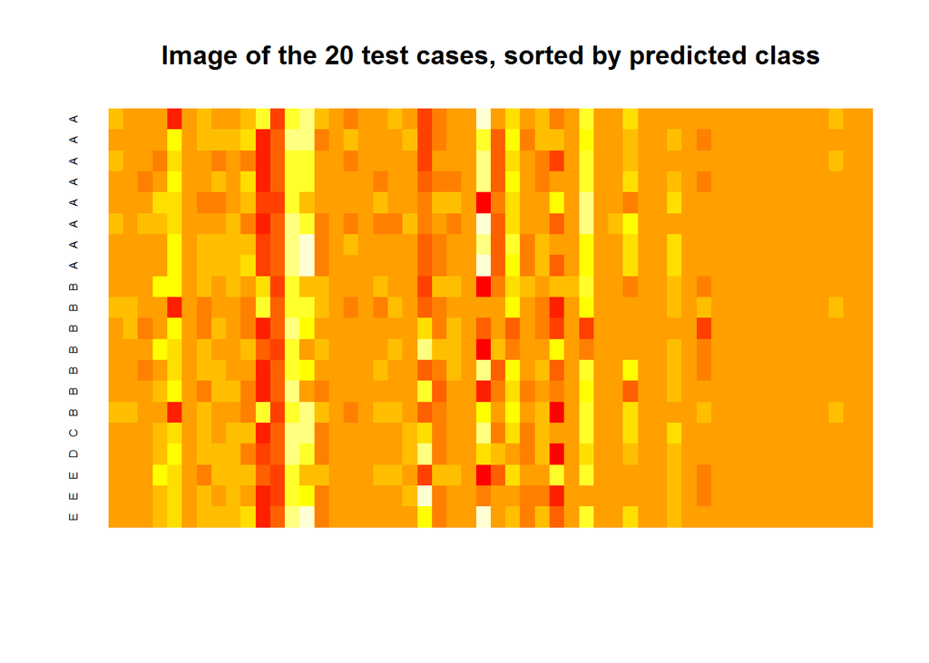

```r
filteredTestcases <- testcases[names(testcases) %in% names(filteredData)]
filteredTestcases <- filteredTestcases[order(imp$importance, decreasing = TRUE)]
filteredTestcases["class"] = pred
filteredTestcases <- filteredTestcases[order(filteredTestcases$class, decreasing = TRUE),]
m = as.matrix(filteredTestcases[,1:52])
x <- (1:nrow(m))
y <- (1:ncol(m))
image(y, x, t(m), axes=FALSE,xlab="",ylab="",srt=45, main="Image of the 20 test cases, sorted by predicted class")
axis(2, at = 1:nrow(m), labels=filteredTestcases$class,srt=45,tick=FALSE, cex.axis=0.5)
```

## 5. Using 10 fold cross-validation

Although the Random Forest algorithm gives an out-of-bag error, we can also try to add an cross-validation step:

```r
train_control <- trainControl(method="cv", number=10)
modFit2 <- train(classe~. , method="rf", trControl=train_control, data=training, prox=TRUE)
print(modFit2$finalModel)
```

```
##
## Call:
##  randomForest(x = x, y = y, mtry = param$mtry, proximity = TRUE)
##                Type of random forest: classification
##                      Number of trees: 500
## No. of variables tried at each split: 27
##
##         OOB estimate of  error rate: 1.87%
## Confusion matrix:
##      A   B   C   D   E class.error
## A 1391   3   1   0   0 0.002867384
## B   18 922   8   1   1 0.029473684
## C    0  13 836   7   0 0.023364486
## D    0   2  21 779   2 0.031094527
## E    1   3   5   6 887 0.016629712
```

```r
varImp(modFit2)
```

```
## rf variable importance
##
##   only 20 most important variables shown (out of 52)
##
##                      Overall
## roll_belt            100.000
## pitch_forearm         64.944
## yaw_belt              47.429
## magnet_dumbbell_z     45.846
## magnet_dumbbell_y     42.118
## pitch_belt            39.048
## roll_forearm          35.839
## roll_dumbbell         23.758
## accel_dumbbell_y      18.705
## magnet_dumbbell_x     18.418
## accel_forearm_x       18.141
## magnet_belt_y         16.113
## magnet_belt_z         15.141
## magnet_forearm_z      13.743
## accel_dumbbell_z      13.518
## total_accel_dumbbell  12.597
## accel_belt_z          11.081
## gyros_dumbbell_y       9.523
## magnet_arm_x           9.355
## magnet_belt_x          9.302
```

We can see that the out-of-bag error rate is not improved, still around 1.8%.

Applying this model to the test cases:

```r
print(predict(modFit2, newdata=testcases))
```

```
##  [1] B A A A A E D B A A B C B A E E A B B B
## Levels: A B C D E
```

We can check that the predicted output is the same as with simple Random Forest.

## 6. Creating the required file output

We use the provided script to write the predicted answers to files.

```r
answers <- predict(modFit1, newdata=testcases)
print(answers)
```

```
##  [1] B A A A A E D B A A B C B A E E A B B B
## Levels: A B C D E
```

```r
pml_write_files = function(x){
  n = length(x)
  for(i in 1:n){
    filename = paste0("problem_id_",i,".txt")
    write.table(x[i],file=filename,quote=FALSE,row.names=FALSE,col.names=FALSE)
  }
}

pml_write_files(answers)
```

Release the resources used for parallel calculations:

```r
stopCluster(cl)
```